# Practical Machine Learing Course Project

## Overview

This project is final requirement in completing the practical machine learning course offered by coursera. In this project, the personal activity data collected from devices such as Jawbone Up, Nike FuelBand, and Fitbit is used as the data set. These type of devices are used by a group of enthusiasts who take measurements about themselves regularly to improve their health, to find patterns in their behavior, or because they are tech geeks. People usually quantify how much of a particular activity they do, but they rarely quantify how well they do it. In this project, the goal is to use this data and predict how well they do certain activitied. In other words, the primary goal is to predict the “classe” variable, the manner in which people did the exercise using the machine learning tools such as caret pacakge and techiniques such as model fitting and prediction.

## Data

The training data for this project are available here: [Training](https://d396qusza40orc.cloudfront.net/predmachlearn/pml-training.csv)

The test data are available here: [Test](https://d396qusza40orc.cloudfront.net/predmachlearn/pml-testing.csv)

### Data Exploratory Analysis and Cleanup

Download the files and load the data into R.

```r
library(caret)
```

```r
library(rpart)
if(!file.exists("pml-training.csv")) {
  url <- "https://d396qusza40orc.cloudfront.net/predmachlearn/pml-training.csv"
  download.file(url, destfile = "pml-training.csv")
}

if(!file.exists("pml-testing.csv")) {
  url <- "https://d396qusza40orc.cloudfront.net/predmachlearn/pml-testing.csv"
  download.file(url, destfile = "pml-testing.csv")
}
#while reading from the csv file treat, "NA","",and "#DIV/0!" all as NAs.
training <- read.csv("pml-training.csv", na.strings=c("NA","","#DIV/0!"))
testing <- read.csv("pml-testing.csv", na.strings=c("NA","","#DIV/0!"))
# count of variables with NAs
length(colnames(training[,colSums(is.na(training)) > 0]))
```

```
## [1] 100
```

There are many varaibles that have majority values as NA. Also, columns 1 to 7 are some meta data about time stamps, user names that will not have any effect on the outcome classe. Hence filtering them out.

```r
training <- training[,-c(1:7)]
training <- training[, colSums(is.na(training))==0]
testing <- testing[,-c(1:7)]
testing <- testing[, colSums(is.na(testing))==0]
```

```r
nrow(training)
```

```
## [1] 19622
```

```r
ncol(training)
```

```
## [1] 53
```

```r
nrow(testing)
```

```
## [1] 20
```

```r
ncol(testing)
```

```
## [1] 53
```

### Modeling Building and Training

#### Cross Validation

Further partitioning the training set into 60 as trainingSubSet and 40% as testingSubSet.

```r
trainPartition <- createDataPartition(training$classe, p=0.6, list=FALSE)
trainingSubSet <- training[trainPartition,]
testingSubSet <- training[-trainPartition,]
dim(trainingSubSet)
```

```
## [1] 11776    53
```

```r
dim(testingSubSet)
```

```
## [1] 7846   53
```

#### Prediction using Decision Trees

```r
set.seed(12345)
# Build the model using the classfication tree algorithm on the trainingSubSet.
dtModel <- train(classe~., data=trainingSubSet,method="rpart")
predDtModel <- predict(dtModel, newdata=testingSubSet)
cMatDT <- confusionMatrix(predDtModel, testingSubSet$classe)
cMatDT
```

```
## Confusion Matrix and Statistics
##
##           Reference
## Prediction    A    B    C    D    E
##          A 1978  646  639  611  196
##          B   43  491   35  224  197
##          C  170  381  694  451  359
##          D    0    0    0    0    0
##          E   41    0    0    0  690
##
## Overall Statistics
##
##                Accuracy : 0.4911
##                  95% CI : (0.48, 0.5022)
##     No Information Rate : 0.2845
##     P-Value [Acc > NIR] : < 2.2e-16
##
##                   Kappa : 0.3349
##  Mcnemar's Test P-Value : NA
##
## Statistics by Class:
##
##                      Class: A Class: B Class: C Class: D Class: E
## Sensitivity            0.8862  0.32345  0.50731   0.0000  0.47850
## Specificity            0.6274  0.92114  0.78990   1.0000  0.99360
## Pos Pred Value         0.4860  0.49596  0.33771      NaN  0.94391
## Neg Pred Value         0.9327  0.85020  0.88361   0.8361  0.89431
## Prevalence             0.2845  0.19347  0.17436   0.1639  0.18379
## Detection Rate         0.2521  0.06258  0.08845   0.0000  0.08794
## Detection Prevalence   0.5187  0.12618  0.26192   0.0000  0.09317
## Balanced Accuracy      0.7568  0.62230  0.64861   0.5000  0.73605
```

#### Prediction using Random Forests

```r
set.seed(12345)
rfModel <- train(classe ~.,data=trainingSubSet,method="rf")
```

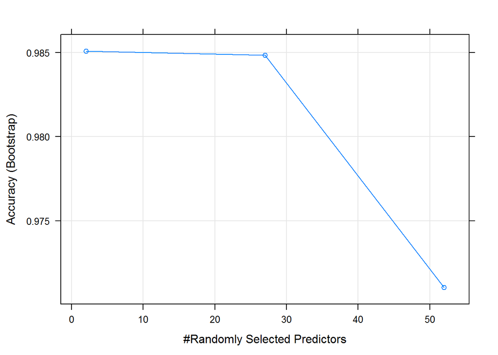

```r
plot(rfModel)
```

```r
predRfModel <- predict(rfModel, newdata=testingSubSet)
cMatRF <- confusionMatrix(predRfModel, testingSubSet$classe)
cMatRF
```

```
## Confusion Matrix and Statistics
##
##           Reference
## Prediction    A    B    C    D    E
##          A 2232    8    0    0    0
##          B    0 1499    8    0    0
##          C    0   11 1359   15    3
##          D    0    0    1 1270    2
##          E    0    0    0    1 1437
##
## Overall Statistics
##
##                Accuracy : 0.9938
##                  95% CI : (0.9918, 0.9954)
##     No Information Rate : 0.2845
##     P-Value [Acc > NIR] : < 2.2e-16
##
##                   Kappa : 0.9921
##  Mcnemar's Test P-Value : NA
##
## Statistics by Class:
##
##                      Class: A Class: B Class: C Class: D Class: E
## Sensitivity            1.0000   0.9875   0.9934   0.9876   0.9965
## Specificity            0.9986   0.9987   0.9955   0.9995   0.9998
## Pos Pred Value         0.9964   0.9947   0.9791   0.9976   0.9993
## Neg Pred Value         1.0000   0.9970   0.9986   0.9976   0.9992
## Prevalence             0.2845   0.1935   0.1744   0.1639   0.1838
## Detection Rate         0.2845   0.1911   0.1732   0.1619   0.1832
## Detection Prevalence   0.2855   0.1921   0.1769   0.1622   0.1833
## Balanced Accuracy      0.9993   0.9931   0.9945   0.9936   0.9982
```

#### Prediction using Generalized Boosted Models

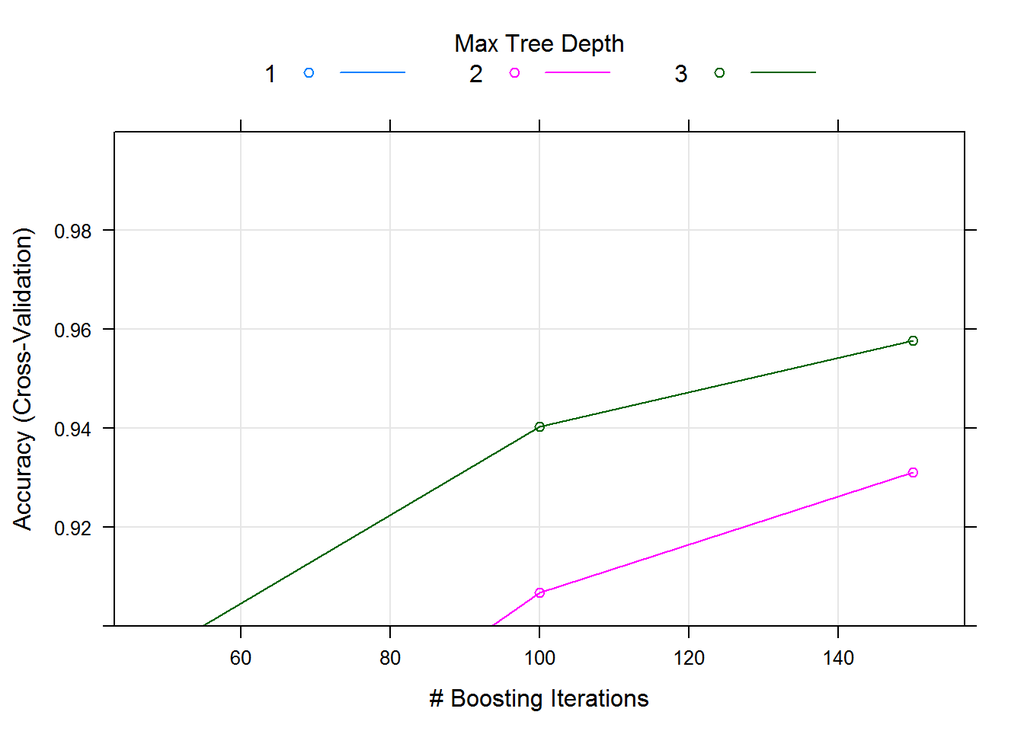

```r
set.seed(12345)
fitControl <- trainControl(method="cv", number=5, verboseIter = FALSE)
gbmModel <- train(classe ~.,data=trainingSubSet,method="gbm", trControl=fitControl, verbose=FALSE)
plot(gbmModel, ylim = c(0.9,1.0))
```

```r
predGbmModel <- predict(gbmModel, newdata=testingSubSet)
cMatGBM <- confusionMatrix(predGbmModel, testingSubSet$classe)
cMatGBM
```

```
FALSE Confusion Matrix and Statistics
FALSE
FALSE           Reference
FALSE Prediction    A    B    C    D    E
FALSE          A 2196   59    0    2    2
FALSE          B   27 1407   43    1   15
FALSE          C    6   49 1292   24   20
FALSE          D    0    2   31 1249   16
FALSE          E    3    1    2   10 1389
FALSE
FALSE Overall Statistics
FALSE
FALSE                Accuracy : 0.9601
FALSE                  95% CI : (0.9555, 0.9643)
FALSE     No Information Rate : 0.2845
FALSE     P-Value [Acc > NIR] : < 2.2e-16
FALSE
FALSE                   Kappa : 0.9495
FALSE  Mcnemar's Test P-Value : 2.575e-07
FALSE
FALSE Statistics by Class:
FALSE
FALSE                      Class: A Class: B Class: C Class: D Class: E
FALSE Sensitivity            0.9839   0.9269   0.9444   0.9712   0.9632
FALSE Specificity            0.9888   0.9864   0.9847   0.9925   0.9975
FALSE Pos Pred Value         0.9721   0.9424   0.9288   0.9622   0.9886
FALSE Neg Pred Value         0.9936   0.9825   0.9882   0.9943   0.9918
FALSE Prevalence             0.2845   0.1935   0.1744   0.1639   0.1838
FALSE Detection Rate         0.2799   0.1793   0.1647   0.1592   0.1770
FALSE Detection Prevalence   0.2879   0.1903   0.1773   0.1654   0.1791
FALSE Balanced Accuracy      0.9863   0.9566   0.9646   0.9819   0.9804
```

### Model Selection and Prediction

- Decision Tree Accuracy = 49.11%
- Random Forest Accuracy = 99.38%
- Generalized Boosted Model Accuracy = 96.01%

The decision tree method of prediction has the lowest accruacy while the random forest method of prediction has the highest accurary 99.38% with an out of sample error rate 100-99.38=0.62%. Hence we are going to use the random forest model as the best model for prediciting the outcome classe. The predicted classe values for the given testing data is:

```r
testingPrediction <- predict(rfModel, newdata=testing)
testingPrediction
```

```
##  [1] B A B A A E D B A A B C B A E E A B B B
## Levels: A B C D E
```

```r
testingPredicted <- testing
testingPredicted$PredictedClasse <- testingPrediction
write.table(testingPredicted, file="pml-testing-predicted.csv", sep = ",", row.names = FALSE)
```